# NFL 2020 Week 15

0.2697

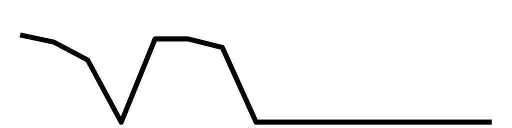

Luca Testa

NA

NA

10

NA

NA

NA

NA

NA

NA

NA

NA

NA

NA

NA

NA

0.0000

1

0.6667

0.0444

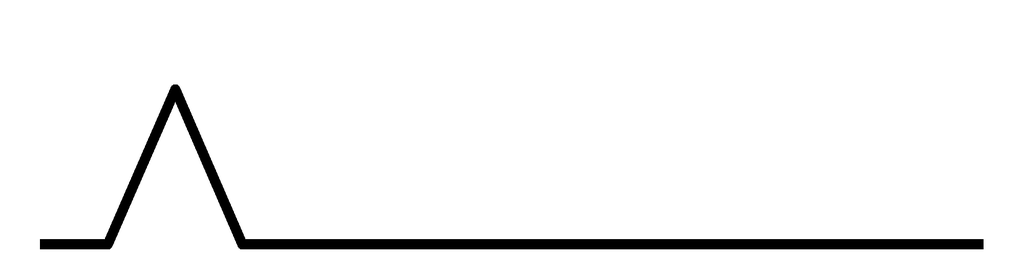

Laurence Dowd

10

10

10

9

10

NA

12

NA

10

8

7

NA

10

NA

NA

0.0000

10

0.6575

0.4383

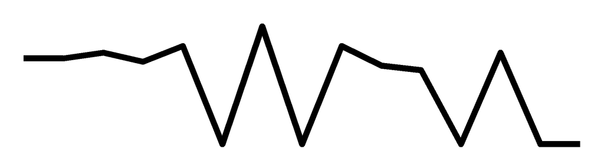

Jonathan Kemp

10

10

NA

NA

11

10

11

7

8

6

8

12

8

9

NA

0.0000

12

0.6286

0.5029

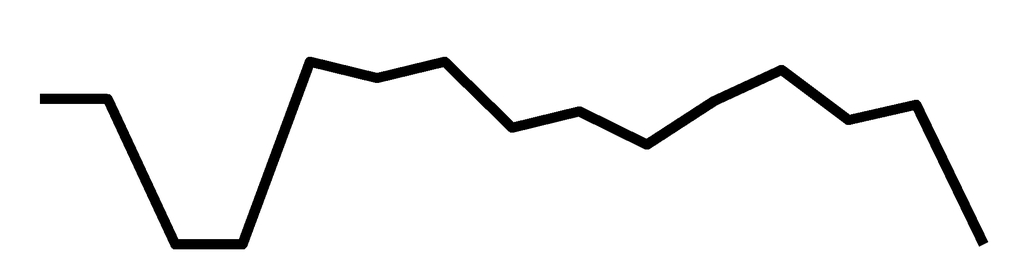

Christopher Erb

9

9

7

11

9

11

8

11

10

9

5

10

9

8

NA

0.0000

14

0.6146

0.5736

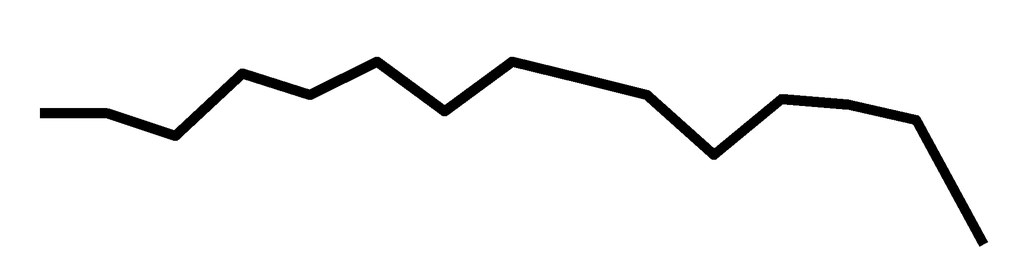

Victor Olawale-Apanpa

8

NA

10

NA

10

NA

10

7

7

9

6

11

10

NA

NA

0.0000

10

0.6069

0.4046

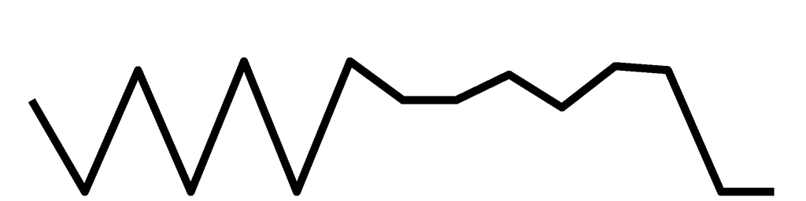

Zakai Bufkin

8

11

7

9

8

10

9

7

9

9

NA

10

NA

NA

NA

0.0000

11

0.5988

0.4391

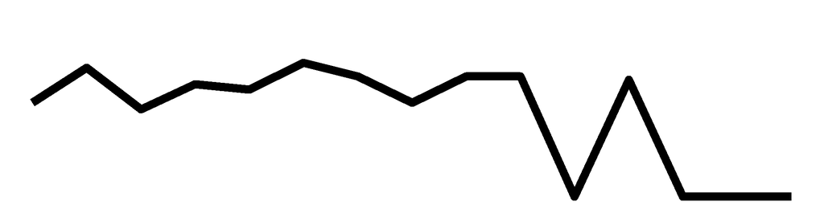

Sidney Cash

10

10

NA

10

NA

8

8

7

11

8

5

10

10

8

NA

0.0000

12

0.5966

0.4773

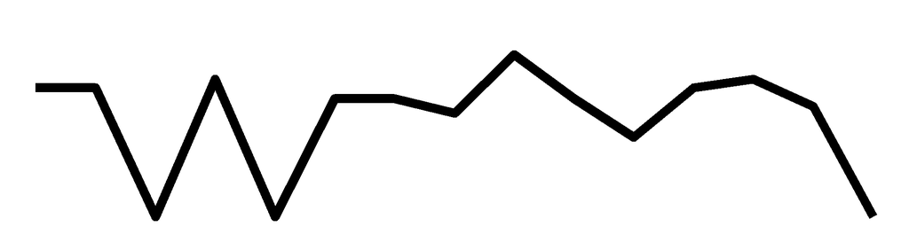

Cameron Patterson

11

9

8

NA

NA

NA

NA

NA

NA

NA

NA

NA

NA

NA

NA

0.0000

3

0.5957

0.1191

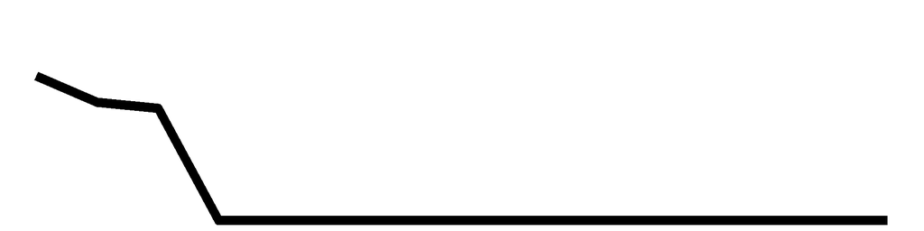

Joshua Gilliard

9

8

9

10

10

7

10

7

5

8

NA

10

10

NA

NA

0.0000

12

0.5819

0.4655

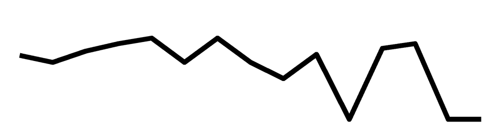

Amadou Bah

9

NA

NA

NA

NA

NA

NA

NA

NA

NA

NA

NA

NA

NA

NA

0.0000

1

0.5625

0.0375

Margaret Williams

9

NA

NA

NA

NA

NA

NA

NA

NA

NA

NA

NA

NA

NA

NA

0.0000

1

0.5625

0.0375

Logan Kauina

9

NA

NA

NA

NA

NA

NA

NA

NA

NA

NA

NA

NA

NA

NA

0.0000

1

0.5625

0.0375

Caleb John

NA

9

NA

NA

NA

NA

NA

NA

NA

NA

NA

NA

NA

NA

NA

0.0000

1

0.5625

0.0375

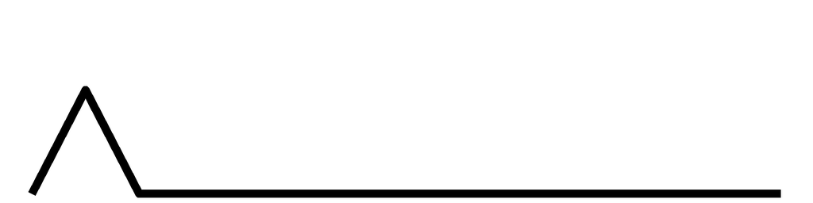

Jay Hajost

11

7

10

NA

6

NA

NA

7

9

NA

NA

NA

NA

NA

NA

0.0000

6

0.5618

0.2247

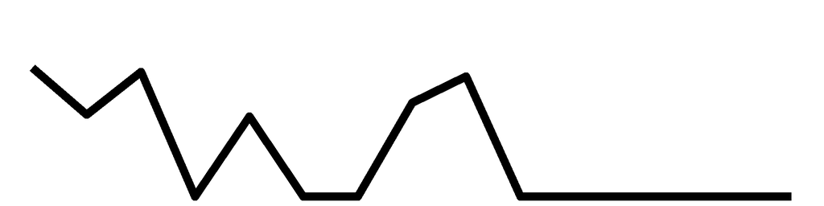

Ryan Jackovic

11

10

NA

7

7

8

8

7

NA

4

5

NA

12

10

NA

0.0000

11

0.5562

0.4079

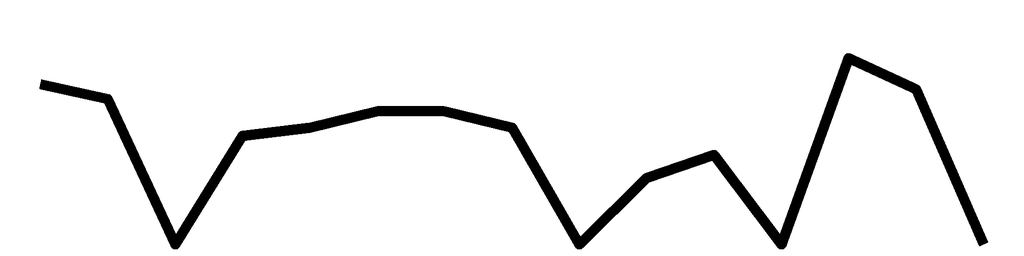

August Rannow

9

NA

NA

NA

7

NA

NA

NA

NA

NA

NA

NA

NA

NA

NA

0.0000

2

0.5333

0.0711

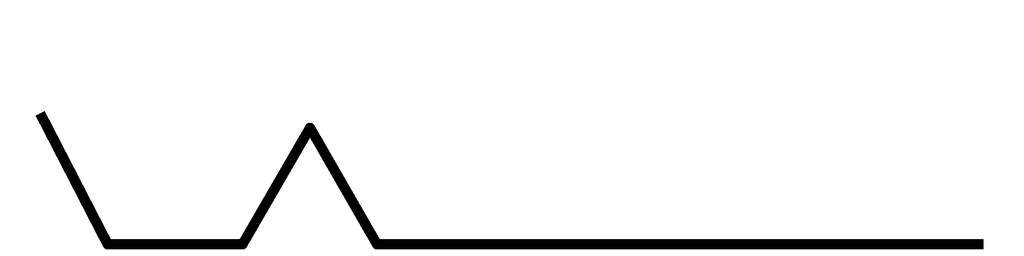

Peter Digenan

9

6

8

10

7

NA

NA

NA

NA

NA

NA

NA

NA

NA

NA

0.0000

5

0.5263

0.1754

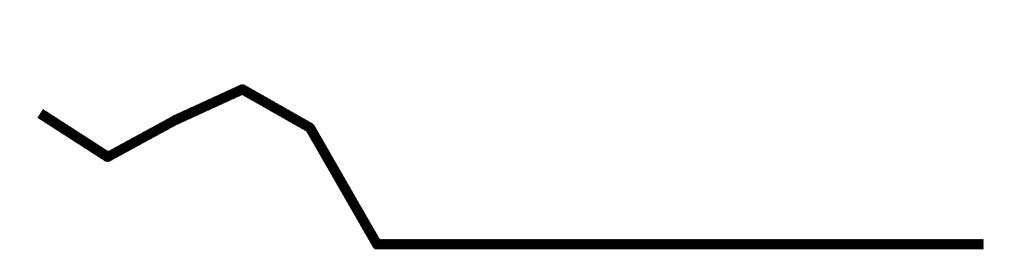

Caleb Doyle

9

NA

NA

NA

NA

NA

NA

6

NA

NA

NA

NA

NA

NA

NA

0.0000

2

0.5000

0.0667

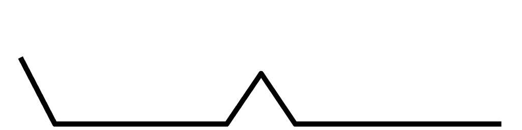

Sydney Johnson

NA

NA

NA

NA

NA

NA

NA

6

NA

NA

NA

NA

NA

NA

NA

0.0000

1

0.4286

0.0286

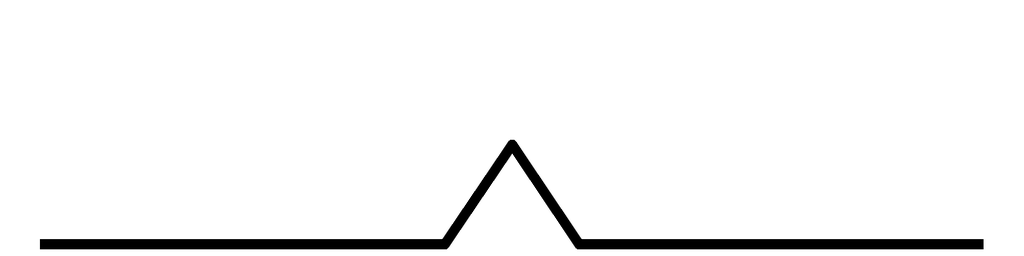

Congrats Caroline Swenson for having the best cadet picks this week, with a correct percentage of 0.75, Congrats Gabriela Peralta for having the best cadet picks this week, with a correct percentage of 0.75, Congrats Joshua Loyd for having the best cadet picks this week, with a correct percentage of 0.75

| Name | Week 1 | Week 2 | Week 3 | Week 4 | Week 5 | Week 6 | Week 7 | Week 8 | Week 9 | Week 10 | Week 11 | Week 12 | Week 13 | Week 14 | Week 15 | Percent | Weeks Picked | Season Percent | Adj Season Percent | Season Trend |
| --- | --- | --- | --- | --- | --- | --- | --- | --- | --- | --- | --- | --- | --- | --- | --- | --- | --- | --- | --- | --- |
| Caroline Swenson | 8 | 12 | 11 | 13 | 7 | 8 | 10 | NA | 8 | 9 | 8 | NA | 12 | 11 | 12 | 0.7500 | 13 | 0.6754 | 0.5853 |  |
| Gabriela Peralta | 11 | 8 | 9 | NA | 8 | 8 | 10 | 6 | NA | 8 | 6 | 10 | 12 | NA | 12 | 0.7500 | 12 | 0.6102 | 0.4882 |  |
| Joshua Loyd | 11 | 9 | 8 | NA | 6 | 9 | NA | 6 | 10 | 8 | NA | 10 | 9 | 11 | 12 | 0.7500 | 12 | 0.6089 | 0.4871 |  |
| Paige Lennon | NA | NA | NA | 11 | 10 | 8 | 11 | 8 | 6 | 8 | 6 | 9 | 11 | 10 | 11 | 0.6875 | 12 | 0.6264 | 0.5011 |  |
| Sydney Shannon | 10 | 9 | 8 | 9 | 8 | 7 | 9 | 5 | 8 | 10 | 8 | 10 | 11 | 10 | 11 | 0.6875 | 15 | 0.6018 | 0.6018 |  |
| John White | 10 | 11 | 10 | 8 | 12 | 9 | 11 | 6 | 9 | 9 | 8 | 10 | 8 | 11 | 10 | 0.6250 | 15 | 0.6425 | 0.6425 |  |
| Thomas Bizub | 10 | 14 | 8 | 11 | 8 | 9 | 10 | 8 | 10 | 12 | 9 | 11 | 9 | 10 | NA | 0.0000 | 14 | 0.678 | 0.6328 |  |
| Kieran Place | 12 | 11 | 8 | NA | 10 | 10 | 9 | NA | NA | NA | NA | NA | NA | NA | NA | 0.0000 | 6 | 0.6742 | 0.2697 |  |
| Luca Testa | NA | NA | 10 | NA | NA | NA | NA | NA | NA | NA | NA | NA | NA | NA | NA | 0.0000 | 1 | 0.6667 | 0.0444 |  |
| Laurence Dowd | 10 | 10 | 10 | 9 | 10 | NA | 12 | NA | 10 | 8 | 7 | NA | 10 | NA | NA | 0.0000 | 10 | 0.6575 | 0.4383 |  |
| Jonathan Kemp | 10 | 10 | NA | NA | 11 | 10 | 11 | 7 | 8 | 6 | 8 | 12 | 8 | 9 | NA | 0.0000 | 12 | 0.6286 | 0.5029 |  |
| Christopher Erb | 9 | 9 | 7 | 11 | 9 | 11 | 8 | 11 | 10 | 9 | 5 | 10 | 9 | 8 | NA | 0.0000 | 14 | 0.6146 | 0.5736 |  |
| Victor Olawale-Apanpa | 8 | NA | 10 | NA | 10 | NA | 10 | 7 | 7 | 9 | 6 | 11 | 10 | NA | NA | 0.0000 | 10 | 0.6069 | 0.4046 |  |
| Zakai Bufkin | 8 | 11 | 7 | 9 | 8 | 10 | 9 | 7 | 9 | 9 | NA | 10 | NA | NA | NA | 0.0000 | 11 | 0.5988 | 0.4391 |  |
| Sidney Cash | 10 | 10 | NA | 10 | NA | 8 | 8 | 7 | 11 | 8 | 5 | 10 | 10 | 8 | NA | 0.0000 | 12 | 0.5966 | 0.4773 |  |
| Cameron Patterson | 11 | 9 | 8 | NA | NA | NA | NA | NA | NA | NA | NA | NA | NA | NA | NA | 0.0000 | 3 | 0.5957 | 0.1191 |  |
| Joshua Gilliard | 9 | 8 | 9 | 10 | 10 | 7 | 10 | 7 | 5 | 8 | NA | 10 | 10 | NA | NA | 0.0000 | 12 | 0.5819 | 0.4655 |  |
| Amadou Bah | 9 | NA | NA | NA | NA | NA | NA | NA | NA | NA | NA | NA | NA | NA | NA | 0.0000 | 1 | 0.5625 | 0.0375 |  |
| Margaret Williams | 9 | NA | NA | NA | NA | NA | NA | NA | NA | NA | NA | NA | NA | NA | NA | 0.0000 | 1 | 0.5625 | 0.0375 |  |
| Logan Kauina | 9 | NA | NA | NA | NA | NA | NA | NA | NA | NA | NA | NA | NA | NA | NA | 0.0000 | 1 | 0.5625 | 0.0375 |  |
| Caleb John | NA | 9 | NA | NA | NA | NA | NA | NA | NA | NA | NA | NA | NA | NA | NA | 0.0000 | 1 | 0.5625 | 0.0375 |  |
| Jay Hajost | 11 | 7 | 10 | NA | 6 | NA | NA | 7 | 9 | NA | NA | NA | NA | NA | NA | 0.0000 | 6 | 0.5618 | 0.2247 |  |
| Ryan Jackovic | 11 | 10 | NA | 7 | 7 | 8 | 8 | 7 | NA | 4 | 5 | NA | 12 | 10 | NA | 0.0000 | 11 | 0.5562 | 0.4079 |  |
| August Rannow | 9 | NA | NA | NA | 7 | NA | NA | NA | NA | NA | NA | NA | NA | NA | NA | 0.0000 | 2 | 0.5333 | 0.0711 |  |
| Peter Digenan | 9 | 6 | 8 | 10 | 7 | NA | NA | NA | NA | NA | NA | NA | NA | NA | NA | 0.0000 | 5 | 0.5263 | 0.1754 |  |
| Caleb Doyle | 9 | NA | NA | NA | NA | NA | NA | 6 | NA | NA | NA | NA | NA | NA | NA | 0.0000 | 2 | 0.5 | 0.0667 |  |
| Sydney Johnson | NA | NA | NA | NA | NA | NA | NA | 6 | NA | NA | NA | NA | NA | NA | NA | 0.0000 | 1 | 0.4286 | 0.0286 |  |

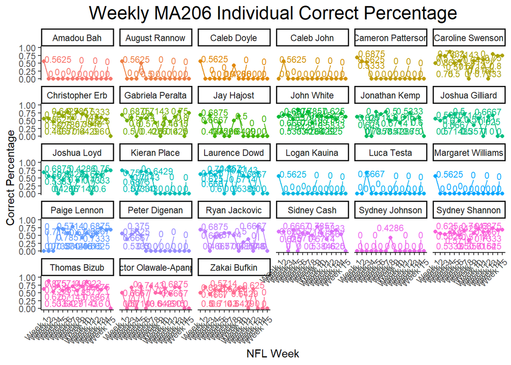

## Combined cadet and instructor prediction

This Week's Combined Cadet and Instructor Predictions

Week 15

| Game | Prediction | Winner | Correct | Correct Votes | Correct Percent |
| --- | --- | --- | --- | --- | --- |
| 1 | Las Vegas Raiders | Los Angeles Chargers | No | 0 | 0.0000 |
| 2 | Buffalo Bills | Buffalo Bills | Yes | 21 | 0.9545 |
| 3 | Green Bay Packers | Green Bay Packers | Yes | 22 | 1.0000 |
| 4 | Miami Dolphins | Miami Dolphins | Yes | 17 | 0.7727 |
| 5 | Seattle Seahawks | Seattle Seahawks | Yes | 20 | 0.9091 |
| 6 | San Francisco 49ers | Dallas Cowboys | No | 5 | 0.2273 |
| 7 | Tampa Bay Buccaneers | Tampa Bay Buccaneers | Yes | 20 | 0.9091 |
| 8 | Baltimore Ravens | Baltimore Ravens | Yes | 22 | 1.0000 |
| 9 | Indianapolis Colts | Indianapolis Colts | Yes | 22 | 1.0000 |
| 10 | Chicago Bears | Chicago Bears | Yes | 15 | 0.6818 |
| 11 | Tennessee Titans | Tennessee Titans | Yes | 21 | 0.9545 |
| 12 | Los Angeles Rams | New York Jets | No | 0 | 0.0000 |
| 13 | Arizona Cardinals | Arizona Cardinals | Yes | 17 | 0.7727 |
| 14 | Kansas City Chiefs | Kansas City Chiefs | Yes | 19 | 0.8636 |
| 15 | Cleveland Browns | Cleveland Browns | Yes | 21 | 0.9545 |
| 16 | Pittsburgh Steelers | Cincinnati Bengals | No | 0 | 0.0000 |

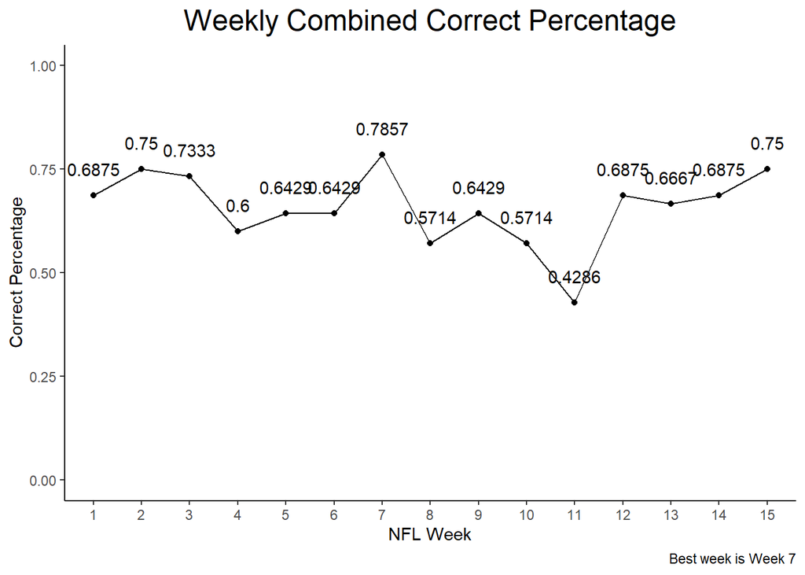

Our combined win percentage for the week is 0.75

Our season combined win percentage so far is 0.6652

22 total predictions this week

This Week's Matched Cadet and Instructor Predictions

Week 15

| Game | Prediction | Correct |
| --- | --- | --- |
| 1 | Las Vegas Raiders | No |
| 2 | Buffalo Bills | Yes |
| 3 | Green Bay Packers | Yes |
| 4 | Miami Dolphins | Yes |
| 5 | Seattle Seahawks | Yes |
| 6 | San Francisco 49ers | No |
| 7 | Tampa Bay Buccaneers | Yes |
| 8 | Baltimore Ravens | Yes |
| 9 | Indianapolis Colts | Yes |
| 10 | Chicago Bears | Yes |
| 11 | Tennessee Titans | Yes |
| 12 | Los Angeles Rams | No |
| 13 | Arizona Cardinals | Yes |
| 14 | Kansas City Chiefs | Yes |
| 15 | Cleveland Browns | Yes |
| 16 | Pittsburgh Steelers | No |

[figure not shown]

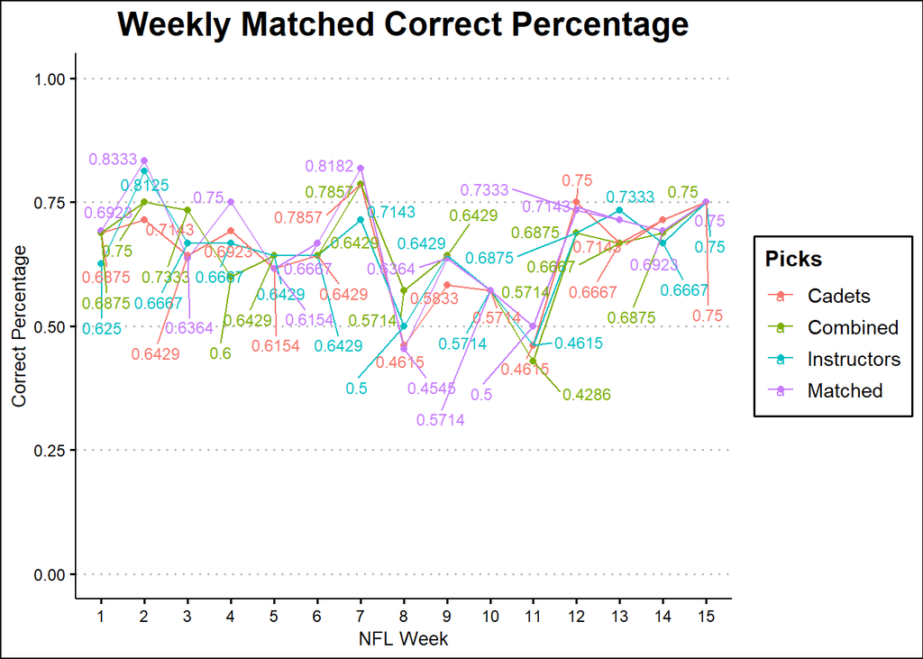